# Ex 5

Guy Blass

# Question 1

### a

```r
data <- read.csv("q1_df.csv")
data %>% group_by(categ) %>% summarise(Count = n())
```

```
## # A tibble: 4 x 2
##   categ Count
##   <int> <int>
## 1     0    11
## 2     1    12
## 3     2    11
## 4     3     6
```

### b

```r
dummy_matrix <- matrix(ncol = 5,nrow = 40)
dummy_matrix[,1] <- data$x
colnames(dummy_matrix) <- c("x","category 0","category 1","category 2","category 3")
for (rownumb in 1:40) {
 ifelse(data[rownumb,]$categ == 0 , dummy_matrix[rownumb,2] <- 1,dummy_matrix[rownumb,2] <- 0)
 ifelse(data[rownumb,]$categ == 1 , dummy_matrix[rownumb,3] <- 1,dummy_matrix[rownumb,3] <- 0)
 ifelse(data[rownumb,]$categ == 2 , dummy_matrix[rownumb,4] <- 1,dummy_matrix[rownumb,4] <- 0)
 ifelse(data[rownumb,]$categ == 3 , dummy_matrix[rownumb,5] <- 1,dummy_matrix[rownumb,5] <- 0)
}
rownames(dummy_matrix) <- paste("row", 1:40, sep = "")
dummy_matrix
```

```
##                x category 0 category 1 category 2 category 3
## row1  0.23303999          0          0          1          0
## row2  0.63843677          1          0          0          0
## row3  0.50946410          0          0          1          0
## row4  0.03885315          1          0          0          0
## row5  0.31385052          0          0          1          0
## row6  0.01674454          0          0          0          1
## row7  0.08214390          0          1          0          0
## row8  0.33073406          0          1          0          0
## row9  2.08343468          1          0          0          0
## row10 0.26568967          0          0          0          1
## row11 0.47589881          1          0          0          0
## row12 0.31201174          0          0          1          0
## row13 0.06957797          0          1          0          0
## row14 0.15814831          0          0          1          0
## row15 0.88606125          0          0          1          0
## row16 0.08471009          0          1          0          0
## row17 0.49427461          0          1          0          0
## row18 0.63923085          1          0          0          0
## row19 0.83870217          0          0          1          0
## row20 1.89817512          1          0          0          0
## row21 0.60746953          0          0          1          0
## row22 0.69127045          0          1          0          0
## row23 0.95885143          0          0          0          1
## row24 0.20532928          0          0          1          0
## row25 2.22941229          0          0          1          0
## row26 0.23124009          0          0          0          1
## row27 2.09514594          0          1          0          0
## row28 0.14384000          1          0          0          0
## row29 0.93393518          0          1          0          0
## row30 0.14244338          0          1          0          0
## row31 0.34660357          1          0          0          0
## row32 0.59410767          1          0          0          0
## row33 0.85823569          1          0          0          0
## row34 1.64893441          0          0          0          1
## row35 0.27353106          0          0          0          1
## row36 0.50880825          0          1          0          0
## row37 0.05287647          0          1          0          0
## row38 0.17633053          1          0          0          0
## row39 0.40124233          0          0          1          0
## row40 1.73198522          0          1          0          0
```

### c

The estimators we got, is how the category is effecting x by the category I omitted, category 3.

```r
data$categ0<-(data$categ==0)
data$categ0[data$categ0=="TRUE"]<-1

data$categ1<-(data$categ==1)
data$categ1[data$categ1=="TRUE"]<-1

data$categ2<-(data$categ==2)
data$categ2[data$categ2=="TRUE"]<-1

data$categ3<-(data$categ==3)
data$categ3[data$categ3=="TRUE"]<-1

qc.matrix<-model.matrix(~data$categ0+data$categ1+data$categ2)
modelqc<-lm(data$x~qc.matrix)
summary(modelqc)
```

```
##
## Call:
## lm(formula = data$x ~ qc.matrix)
##
## Residuals:
##     Min      1Q  Median      3Q     Max
## -0.6787 -0.4151 -0.2245  0.1630  1.6208
##
## Coefficients: (1 not defined because of singularities)
##                      Estimate Std. Error t value Pr(>|t|)
## (Intercept)           0.56583    0.26393   2.144   0.0389 *
## qc.matrix(Intercept)       NA         NA      NA       NA
## qc.matrixdata$categ0  0.15173    0.32810   0.462   0.6466
## qc.matrixdata$categ1  0.03566    0.32324   0.110   0.9128
## qc.matrixdata$categ2  0.04278    0.32810   0.130   0.8970
## ---
## Signif. codes:  0 '***' 0.001 '**' 0.01 '*' 0.05 '.' 0.1 ' ' 1
##
## Residual standard error: 0.6465 on 36 degrees of freedom
## Multiple R-squared:  0.008162,   Adjusted R-squared:  -0.07449
## F-statistic: 0.09876 on 3 and 36 DF,  p-value: 0.9602
```

# Question 2

### a

In this dataset we have 7 different fish spices and their dimensions and weight

```r
fish <- read_csv("Fish.csv")
summary(fish)
```

```
##    Species              Weight          Length1         Length2
##  Length:159         Min.   :   0.0   Min.   : 7.50   Min.   : 8.40
##  Class :character   1st Qu.: 120.0   1st Qu.:19.05   1st Qu.:21.00
##  Mode  :character   Median : 273.0   Median :25.20   Median :27.30
##                     Mean   : 398.3   Mean   :26.25   Mean   :28.42
##                     3rd Qu.: 650.0   3rd Qu.:32.70   3rd Qu.:35.50
##                     Max.   :1650.0   Max.   :59.00   Max.   :63.40
##     Length3          Height           Width
##  Min.   : 8.80   Min.   : 1.728   Min.   :1.048
##  1st Qu.:23.15   1st Qu.: 5.945   1st Qu.:3.386
##  Median :29.40   Median : 7.786   Median :4.248
##  Mean   :31.23   Mean   : 8.971   Mean   :4.417
##  3rd Qu.:39.65   3rd Qu.:12.366   3rd Qu.:5.585
##  Max.   :68.00   Max.   :18.957   Max.   :8.142
```

```r
length(unique(fish$Species))
```

```
## [1] 7
```

### b

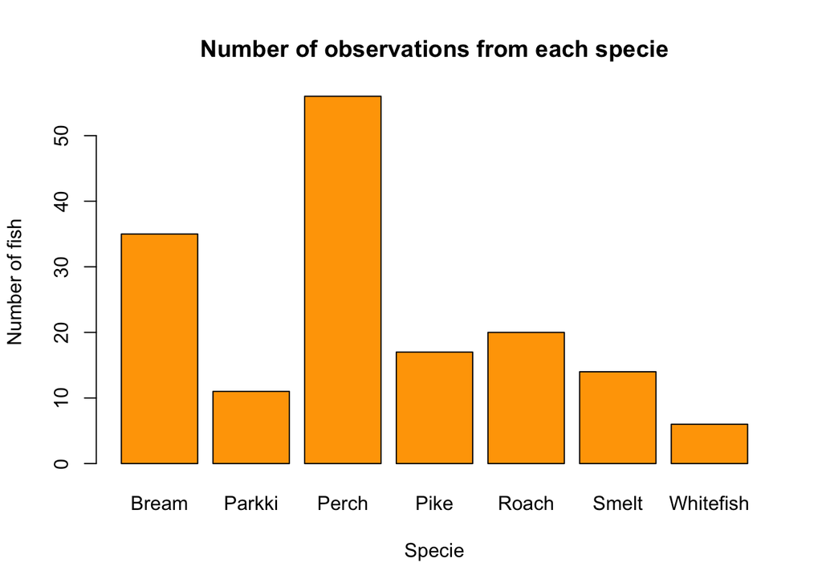

```r
var1 <- table(fish$Species)
barplot(var1, xlab = "Specie",ylab = "Number of fish", main = "Number of observations from each specie",col = "orange")
```

### c

We will want to add an parameter that his value will be 1 to use the $\beta$ of an specific specie The parameter value will be 0 if we don’t want to include the specie.

### d

```r
factored <- as.factor(fish$Species)
lm.q2d <- lm(fish$Weight ~ relevel(factored, ref= "Whitefish") + fish$Length1 +
  fish$Length2 + fish$Length3 + fish$Height + fish$Width)
summary(lm.q2d)
```

```
##
## Call:
## lm(formula = fish$Weight ~ relevel(factored, ref = "Whitefish") +
##     fish$Length1 + fish$Length2 + fish$Length3 + fish$Height +
##     fish$Width)
##
## Residuals:
##     Min      1Q  Median      3Q     Max
## -213.18  -53.19  -12.62   36.49  420.82
##
## Coefficients:
##                                             Estimate Std. Error t value
## (Intercept)                                -824.4580    67.5809 -12.200
## relevel(factored, ref = "Whitefish")Bream   -93.8742    96.6580  -0.971
## relevel(factored, ref = "Whitefish")Parkki   70.8485    61.4053   1.154
## relevel(factored, ref = "Whitefish")Perch    44.0747    52.9384   0.833
## relevel(factored, ref = "Whitefish")Pike   -302.3035    83.9441  -3.601
## relevel(factored, ref = "Whitefish")Roach     9.1658    47.6521   0.192
## relevel(factored, ref = "Whitefish")Smelt   352.1991    62.8571   5.603
## fish$Length1                                -80.3030    36.2785  -2.214
## fish$Length2                                 79.8886    45.7180   1.747
## fish$Length3                                 32.5354    29.3002   1.110
## fish$Height                                   5.2510    13.0560   0.402
## fish$Width                                   -0.5154    23.9130  -0.022
##                                            Pr(>|t|)
## (Intercept)                                 < 2e-16 ***
## relevel(factored, ref = "Whitefish")Bream  0.333045
## relevel(factored, ref = "Whitefish")Parkki 0.250461
## relevel(factored, ref = "Whitefish")Perch  0.406440
## relevel(factored, ref = "Whitefish")Pike   0.000432 ***
## relevel(factored, ref = "Whitefish")Roach  0.847735
## relevel(factored, ref = "Whitefish")Smelt  1.01e-07 ***
## fish$Length1                               0.028403 *
## fish$Length2                               0.082653 .
## fish$Length3                               0.268633
## fish$Height                                0.688128
## fish$Width                                 0.982832
## ---
## Signif. codes:  0 '***' 0.001 '**' 0.01 '*' 0.05 '.' 0.1 ' ' 1
##
## Residual standard error: 93.83 on 147 degrees of freedom
## Multiple R-squared:  0.9361, Adjusted R-squared:  0.9313
## F-statistic: 195.7 on 11 and 147 DF,  p-value: < 2.2e-16
```

### e

```r
beta.1.tval <- -0.971
beta.2.tval <- 1.154
beta.3.tval <- 0.833
beta.4.tval <- -3.601
beta.5.tval <- 0.192
beta.6.tval <- 5.603
beta.7.tval <- -2.214
beta.8.tval <- 1.747
beta.9.tval <- 1.110
beta.10.tval <- 0.402
beta.11.tval <- -0.022

abs(beta.1.tval) > qt(0.975,159-12)
```

```
## [1] FALSE
```

```r
abs(beta.2.tval) > qt(0.975,159-12)
```

```
## [1] FALSE
```

```r
abs(beta.3.tval) > qt(0.975,159-12)
```

```
## [1] FALSE
```

```r
abs(beta.4.tval) > qt(0.975,159-12)
```

```
## [1] TRUE
```

```r
abs(beta.5.tval) > qt(0.975,159-12)
```

```
## [1] FALSE
```

```r
abs(beta.6.tval) > qt(0.975,159-12)
```

```
## [1] TRUE
```

```r
abs(beta.7.tval) > qt(0.975,159-12)
```

```
## [1] TRUE
```

```r
abs(beta.8.tval) > qt(0.975,159-12)
```

```
## [1] FALSE
```

```r
abs(beta.9.tval) > qt(0.975,159-12)
```

```
## [1] FALSE
```

```r
abs(beta.10.tval) > qt(0.975,159-12)
```

```
## [1] FALSE
```

```r
abs(beta.11.tval) > qt(0.975,159-12)
```

```
## [1] FALSE
```

### f

Because the specie Whitefish was used as a reference for all the other species, we cannot do a hypothesis testing for him. We don’t have his coefficient and we cannot do hypothesis testing without it

### g

The meaning of the coefficient of $\beta_j$ that we got from our regression, is how much the specie is affecting the weight of our fish.